# TLimmuno2 can learn important features that determine immunogenicity

- Immunotherapy
- Immunoediting

## Immunotherapy

To further validate TLimmuno2 and demonstrate the value of our model as a knowledge discovery tool, we evaluated the physiological relevance of TLimmuno2’s prediction. Most current cancer vaccine platforms preferentially screen candidate neoepitopes for vaccine production by selecting highly expressed candidate neoepitopes with high binding affinity to HLA alleles. However, despite rigorous candidate selection, many vaccine peptides do not elicit T-cell responses after vaccination. Therefore, we compare the performance of TLimmuno2 and NetMHCIIpan by using personalized melanoma neoepitopes with corresponding immune response data

```python
import pandas as pd
import numpy as np
import seaborn as sns
import matplotlib.pyplot as plt
import matplotlib as mpl
mpl.rcParams['pdf.fonttype'] = 42
mpl.rcParams['ps.fonttype'] = 42
plt.rcParams.update({'font.family':'Arial'})
from sklearn.metrics import accuracy_score, recall_score, f1_score, precision_score
```

```python
def IMM_process_rank(Data,peptide):
    sam_pep_ID = Data["pep_ID"].unique()
    res = []
    p_ID = []
    Data["length"] = Data["pep"].map(len)
    for a in sam_pep_ID:
        Mean = []
        ID = Data[Data["pep_ID"] == a]
        for i in ID["HLA"].unique():
            Data_HLA = ID[ID["HLA"] == i]
            prediction = []
            for l in Data_HLA["length"].unique():
                Data_len = Data_HLA[Data_HLA["length"] == l]
                pre = Data_len["Rank"].min()
                prediction.append(pre)
            x_mean = np.min(prediction)
            Mean.append(x_mean)
        res.append(min(Mean))
        p_ID.append(a)
    result = pd.DataFrame({"pep_ID":p_ID,"prediction":res})
    result = result.merge(peptide,how = "inner",on = "pep_ID" )
    return result
def netMHCIIpan_process(result,allele,ori_sorted,peptide):
    #combine two type allele
    result = pd.merge(result,allele,left_on="allele",right_on="Allele Name")
    result_sorted = result.sort_values(by=["peptide","HLA"]).reset_index(drop = True)
    #combine with ori data
    result_combined = pd.merge(result_sorted,ori_sorted[["pep","pep_ID"]],left_on = "peptide",right_on ="pep")
    #result_combined["pep_length"] = result_combined["peptide"].map(len)
    sam_pep_ID = result_combined["pep_ID"].unique()
    res = []
    p_ID = []
    for a in sam_pep_ID:
        Mean = []
        ID = result_combined[result_combined["pep_ID"] == a]
        #get Mean of all splited pep and Max of all HLA
        for i in ID["Allele Name"].unique():
            Data_HLA = ID[ID["Allele Name"] == i]
            prediction = []
            for l in Data_HLA["pep_length"].unique():
                Data_len = Data_HLA[Data_HLA["pep_length"] == l]
                pre = Data_len["percentile_rank"].min()
                prediction.append(pre)
            x = np.min(prediction)
        res.append(np.min(x))
        p_ID.append(a)
    final_result = pd.DataFrame({"pep_ID":p_ID,"prediction":res})
    final_result = final_result.merge(peptide,how = "inner",on = "pep_ID" )
    return final_result
patient_id = ["O.1","O.2","O.3","O.4","O.5","O.6"]
DF15 = pd.read_csv("/Users/wangguangshuai/Data/MHCII/Data/IMM_model_benchmark/DF15.csv")
```

```python
result_15 = pd.read_csv("/Users/wangguangshuai/Data/MHCII/Data/IMM_model_benchmark/15mer_rank_result.csv")
peptide= pd.read_csv("../data/peptide.csv")
Rank_15mer = IMM_process_rank(result_15,peptide)
DF15_sorted = DF15.sort_values(by=["pep","HLA"]).reset_index(drop = True)
allele = pd.read_csv("/Users/wangguangshuai/Data/MHCII/Data/IMM_model_benchmark/allele.csv")
netMHCIIpan_ba = pd.read_csv("/Users/wangguangshuai/Data/MHCII/Data/IMM_model_benchmark/netMHCIIpan_15_mer_ba.csv")
netMHCIIpan_ba["pep_length"] = netMHCIIpan_ba["peptide"].map(len)
net_15mer_ba = netMHCIIpan_process(netMHCIIpan_ba,allele,DF15_sorted,peptide)
netMHCIIpan_el = pd.read_csv("/Users/wangguangshuai/Data/MHCII/Data/IMM_model_benchmark/netMHCIIpan_15_mer_el.csv")
netMHCIIpan_el["pep_length"] = netMHCIIpan_el["peptide"].map(len)
net_15mer_el = netMHCIIpan_process(netMHCIIpan_el,allele,DF15_sorted,peptide)
ott_net_ba = net_15mer_ba[net_15mer_ba["Patient_ID"].map(lambda x : x in patient_id)]
ott_net_el = net_15mer_el[net_15mer_el["Patient_ID"].map(lambda x : x in patient_id)]
ott_imm = Rank_15mer[Rank_15mer["Patient_ID"].map(lambda x : x in patient_id)]
```

```python
def call_value(data,net = True):
  if net:
    preds = data["prediction"].map(lambda x : 1 if x <=2 else 0)
  else:
    preds = data["prediction"].map(lambda x : 1 if x <=0.02 else 0)
  trues = data["Immunogenicity"]
  acc = accuracy_score(trues, preds)
  p = precision_score(trues, preds)
  r = recall_score(trues, preds)
  f1= f1_score(trues, preds)

  return acc,p,r,f1
```

```python
#top20&top50
from collections import Counter
ott_imm_sorted = ott_imm.sort_values(by="prediction")
ott_net_el_sorted = ott_net_el.sort_values(by="prediction")
ott_net_ba_sorted = ott_net_ba.sort_values(by="prediction")
ott_imm_sorted["pre_label"] = ott_imm_sorted["prediction"].map(lambda x : 1 if x <=0.02 else 0)
ott_net_el_sorted["pre_label"] = ott_net_el_sorted["prediction"].map(lambda x : 1 if x <=2 else 0)
ott_net_ba_sorted["pre_label"] = ott_net_ba_sorted["prediction"].map(lambda x : 1 if x <=2 else 0)
def call_top(x):
  x20 = x[0:20]
  top20 = Counter(x20["Immunogenicity"] == x20["pre_label"])[True]
  x50 = x[0:50]
  top50 = Counter(x50["Immunogenicity"] == x50["pre_label"])[True]

  return top20,top50
imm20,imm50 = call_top(ott_imm_sorted)
net_ba20,net_ba50 = call_top(ott_net_ba_sorted)
net_el20,net_el50 = call_top(ott_net_el_sorted)
top20 = [imm20,net_ba20,net_el20]
top50 = [imm50,net_ba50,net_el50]
```

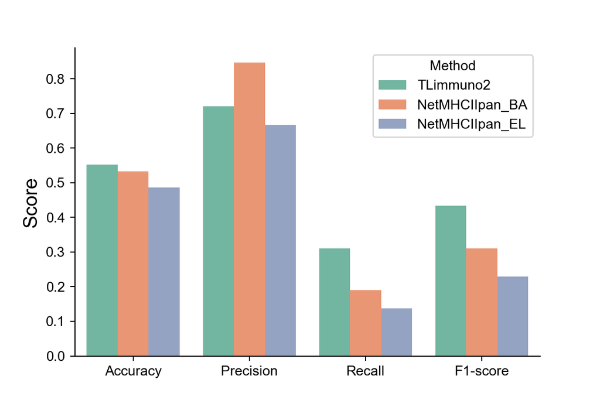

```python
imm = call_value(ott_imm,False)
net_ba = call_value(ott_net_ba)
net_el = call_value(ott_net_el)
data = pd.DataFrame([imm,net_ba,net_el], index = ["TLimmuno2","NetMHCIIpan_BA","NetMHCIIpan_EL"],columns = ["Accuracy","Precision","Recall","F1-score"])
data["Method"] = data.index
data = data.melt(id_vars = "Method")
fig,ax = plt.subplots(figsize = (6,4))
sns.barplot(x = "variable",y = "value", hue = "Method",data = data,palette = "Set2")
ax.set_xlabel("")
ax.set_ylabel("Score",fontsize = 14)
ax.spines["top"].set_visible(False)
ax.spines["right"].set_visible(False)
plt.savefig("../figure/neoantigen_vaccine.pdf",dpi = 300,transparent=True)
plt.show()
```

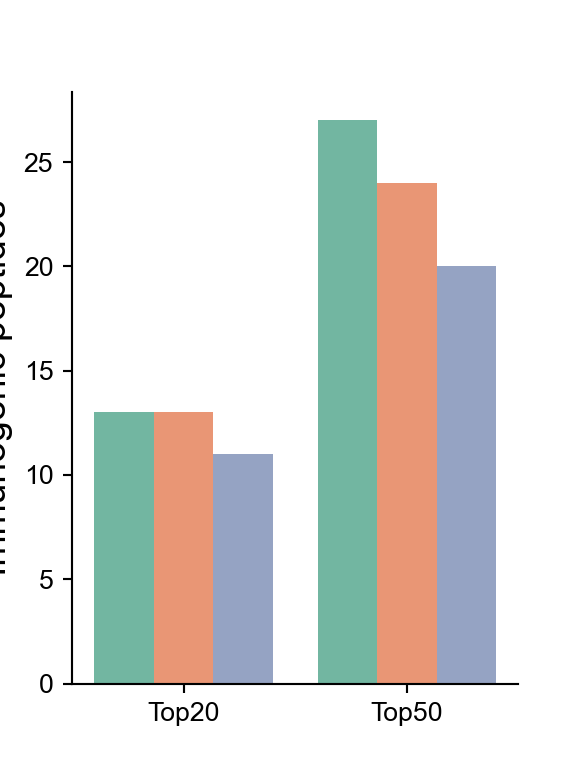

```python
data = pd.DataFrame([top20,top50], columns = ["TLimmuno2","netMHCIIpan_ba","netMHCIIpan_el"],index = ["Top20","Top50"])
data["Method"] = data.index
data = data.melt(id_vars = "Method")
fig,ax = plt.subplots(figsize = (3,4))
sns.barplot(x = "Method",y = "value", hue = "variable",data = data,palette = "Set2")
ax.set_xlabel("")
ax.get_legend().remove()
ax.set_ylabel("Immunogenic peptides",fontsize = 14)
ax.spines["top"].set_visible(False)
ax.spines["right"].set_visible(False)
plt.savefig("../figure/neoantigen_top20&50.pdf",dpi = 300,bbox_inches='tight',transparent=True)
plt.show()
```